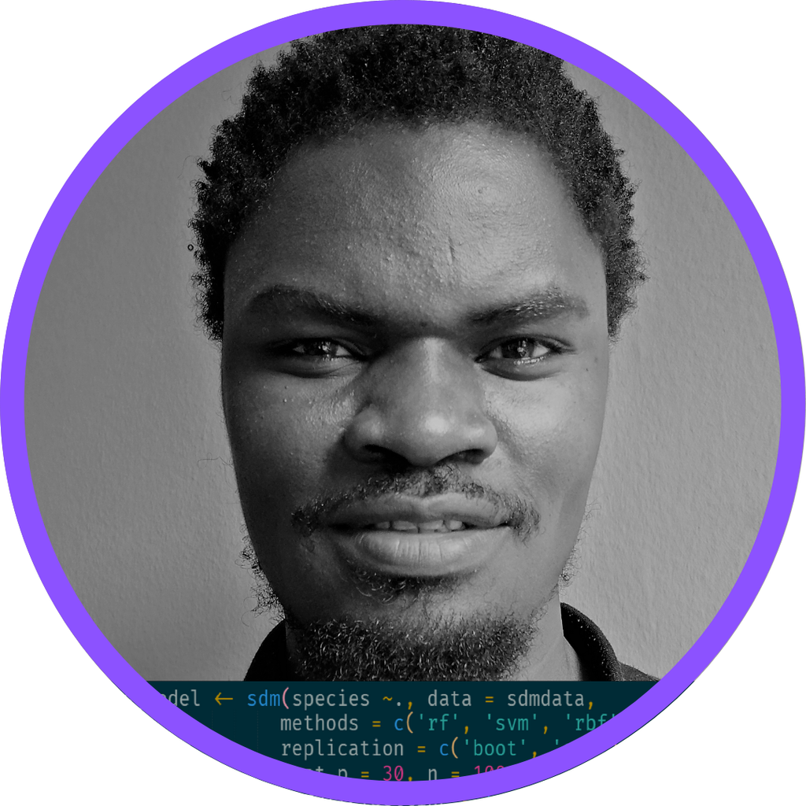

# Wyclife Agumba Oluoch

## **`Who am I?`**

I am a Geospatial Data Analyst who uses **Machine Learning** 💻 and **Deep Learning** 🧠 approaches and applications to map **biodiversity** 🌳🎋🐦🐟🦌 and **field crops** 🧑‍🌾 at local, regional, and global scales 🌍. These help in ensuring sustainable use of such resources and guiding relevant policy interventions. In that endeavor, I rely on big data on platforms such as **`R`**, **`Python`** 🐍 and **`Google Earth Engine`**. I also embrace Shell scripting, High Performance Computing, and Cloud Computing with such big data. Besides, I find fun in counter-intuitive debates around **whys** and **what ifs**.

## **`Experience`**

**University of Bonn** | Bonn - ILR [Land Economics Group](https://www.ilr1.uni-bonn.de/en/research/research-groups/land-economics), | NRW - Bonn, Germany

Postdoctoral researcher | December 2023 - Present

**KALRO - Tea Research Institute** | [KALRO - Tea Research Institute](https://www.kalro.org/tea/) | Kericho, Kenya

Environmentalist Intern | May 2015 - October 2019

## **`Education Background`**

[**University of Bonn**](https://www.uni-bonn.de/en/university/university) | NRW - Bonn, Germany

Doctor of Agricultural Sciences (Dr. agr.) | October 2019 - April 2024

[**Maseno University**](https://www.maseno.ac.ke/) | Maseno, Kenya

M.A. in Geography | September 2013 - December 2018

[**Moi University**](http://mu.ac.ke/) | Eldoret, Kenya

B.A. in Geography | August 2008 - August 2012

## **`Recent Publications 2020-Date`**

1. Predicted changes in distribution and richness of wild edible plants under climate change scenarios in northwestern Kenya [link](https://link.springer.com/article/10.1007/s10113-023-02175-3).
2. Integrated Participatory Approach Reveals Perceived Local Availability of Wild Edible Plants in Northwestern Kenya [link](https://doi.org/10.1007/s10745-023-00405-0).
3. Indigenous communities’ perceptions reveal threats and management options of wild edible plants in semiarid lands of northwestern Kenya [link](https://doi.org/10.1186/s13002-023-00584-6).
4. Predicting the potential impacts of climate change on the endangered endemic annonaceae species in east africa [link](https://doi.org/10.1016/j.heliyon.2023.e17405).
5. Modeling impacts of climate change on the potential distribution of three endemic *Aloe* species critically endangered in East Africa [link](https://doi.org/10.1016/j.ecoinf.2022.101765).
6. Combating Climate Change in the Kenyan Tea Industry [link](https://doi.org/10.3389/fpls.2020.00339).

## **`Works in progress`**

1. Impact of land degradation and climate change on livelihoods of **tea** and **coffee** farmers globally. In this, I create global maps of tea and coffee fields using high resolution satellite images and visually interpreted cropland polygons within deep learning and machine learning frameworks. The work is not only relevant for the livelihoods of the farmers but also in assessing amount of such crops coming from deforested lands as regulated in the European Commission Regulation on Deforestation-free products [link](https://environment.ec.europa.eu/topics/forests/deforestation/regulation-deforestation-free-products_en).
2. Evaluating the impact of land restoration project [Restor](https://restor.eco/?lat=26&lng=14.23&zoom=3) on net primary productivity and greenness globally. I am part of this project with a team from [Land Economics](https://www.ilr1.uni-bonn.de/en/research/research-groups/land-economics) group trying to evaluate whether the restored sites differ from synthetic controls by using a number of relevant variables.
3. Detecting where mechanization agriculture is profitable across the globe. I am contributing in this project within the [Land Economics](https://www.ilr1.uni-bonn.de/en/research/research-groups/land-economics) group by tuning machine learning models. Knowing where in the globe mechanization is profitable is helpful in guiding policy recommendations for deploying mechanized activities in the field.
4. Assessing the long term policy implications on bird species richness within grasslands across the globe. In this study within [Land Economics](https://www.ilr1.uni-bonn.de/en/research/research-groups/land-economics) group, my role is to help with machine learning model formulation to help reveal the relevance of policy changes on bird species richness.
5. Evaluating the impact of weirs on ecosystem health within dry river valleys of Ethiopia. This is also a project within the [Land Economics](https://www.ilr1.uni-bonn.de/en/research/research-groups/land-economics) group where we check whether the ecosystem within the sub-catchments around weirs have better ecosystem health than the control sites.